# Tugas Praktikum MPDW - Pertemuan 4

# No. 1 : Proses MA(2)

Model yang dibangkitkan:

$$Y_t = e_t + \theta_1 e_{t-1} + \theta_2 e_{t-2}, \quad \theta_1 = 0.4,\
\theta_2 = 0.6,\ n = 300$$

## a. Bangkitkan model MA(2) sebanyak 300 data (Manual dan dengan `arima.sim`)

**Manual**

```r
set.seed(1234)
n <- 300
wn.ma2 <- rnorm(n)

# nilai awal (dua observasi pertama disamakan dengan white noise)
ma2 <- wn.ma2[1:2]

for (i in 3:n) {
  ma2[i] <- wn.ma2[i] + 0.4 * wn.ma2[i - 1] + 0.6 * wn.ma2[i - 2]
}
ma2
```

```
##   [1] -1.207065749  0.277429242  0.471173424 -1.745463687  0.141510314
##   [6] -0.729712854 -0.114842790 -0.472894305 -1.127948717 -1.443797742
##  [11] -1.171879031 -1.723286222 -1.461924092 -0.845074607  0.519525249
##  [16]  0.312187420  0.020572732 -1.181770516 -1.508255550  1.534249256
##  [21]  0.598119283  1.012450498 -0.556369299 -0.011041246 -0.774213194
##  [26] -1.449939345 -0.420758391 -1.662676381 -0.079747157 -1.556197355
##  [31]  0.718835126 -0.596243221 -0.238298741 -1.070389923 -2.255260716
##  [36] -2.120011486 -3.624543435 -2.913580609 -2.138714925 -1.388210999
##  [41]  1.086560934 -0.768382742 -0.413123964 -1.263954490 -1.619808057
##  [46] -1.534624150 -2.091327966 -2.276021753 -1.689013389 -1.457572736
##  [51] -2.319068111 -1.602598402 -2.425338748 -1.807763414 -1.233628102
##  [56] -0.110845196  1.775654086  0.223607057  2.285258743 -0.979456751
##  [61]  1.157010823  2.116941328  1.378789117  0.845856907 -0.296314421
##  [66]  1.372262398 -0.432336811  1.978634754  1.193531021  1.688995021
##  [71]  0.939220832 -0.250827924 -0.544575725  0.228395751  2.109671129
```

[output cut: 45 more lines]

**`arima.sim()`**

```r
set.seed(1234)
ma2.sim <- arima.sim(list(order = c(0, 0, 2), ma = c(0.4, 0.6)), n = 300)
ma2.sim
```

```
## Time Series:
## Start = 1
## End = 300
## Frequency = 1
##   [1]  0.471173424 -1.745463687  0.141510314 -0.729712854 -0.114842790
##   [6] -0.472894305 -1.127948717 -1.443797742 -1.171879031 -1.723286222
##  [11] -1.461924092 -0.845074607  0.519525249  0.312187420  0.020572732
##  [16] -1.181770516 -1.508255550  1.534249256  0.598119283  1.012450498
##  [21] -0.556369299 -0.011041246 -0.774213194 -1.449939345 -0.420758391
##  [26] -1.662676381 -0.079747157 -1.556197355  0.718835126 -0.596243221
##  [31] -0.238298741 -1.070389923 -2.255260716 -2.120011486 -3.624543435
##  [36] -2.913580609 -2.138714925 -1.388210999  1.086560934 -0.768382742
##  [41] -0.413123964 -1.263954490 -1.619808057 -1.534624150 -2.091327966
##  [46] -2.276021753 -1.689013389 -1.457572736 -2.319068111 -1.602598402
##  [51] -2.425338748 -1.807763414 -1.233628102 -0.110845196  1.775654086
```

[output cut: 49 more lines]

Kedua cara menghasilkan 300 data proses MA(2). Cara manual dilakukan dengan *loop* yang menjumlahkan white noise saat ini ($e_t$) dengan 0.4 kali white noise satu periode sebelumnya dan 0.6 kali white noise dua periode sebelumnya, sesuai bentuk model MA(2) di atas. Cara `arima.sim()` menghasilkan data dengan pola yang serupa secara lebih ringkas karena rumus pembangkitannya sudah diimplementasikan langsung oleh fungsi tersebut.

## b. Plot time series, ACF, PACF, EACF, serta identifikasi kestasioneran

**Plot Time Series**

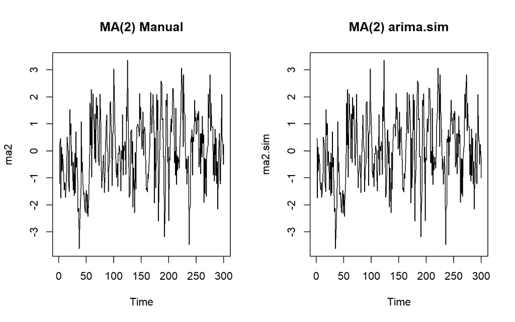

```r
par(mfrow = c(1, 2))
ts.plot(ma2, main = "MA(2) Manual")
ts.plot(ma2.sim, main = "MA(2) arima.sim")
```

```r
par(mfrow = c(1, 1))
```

Kedua data bergerak di sekitar nilai tengah yang konstan tanpa pola tren maupun perubahan lebar pita yang berarti, sehingga data **stasioner dalam rataan**.

**Plot ACF**

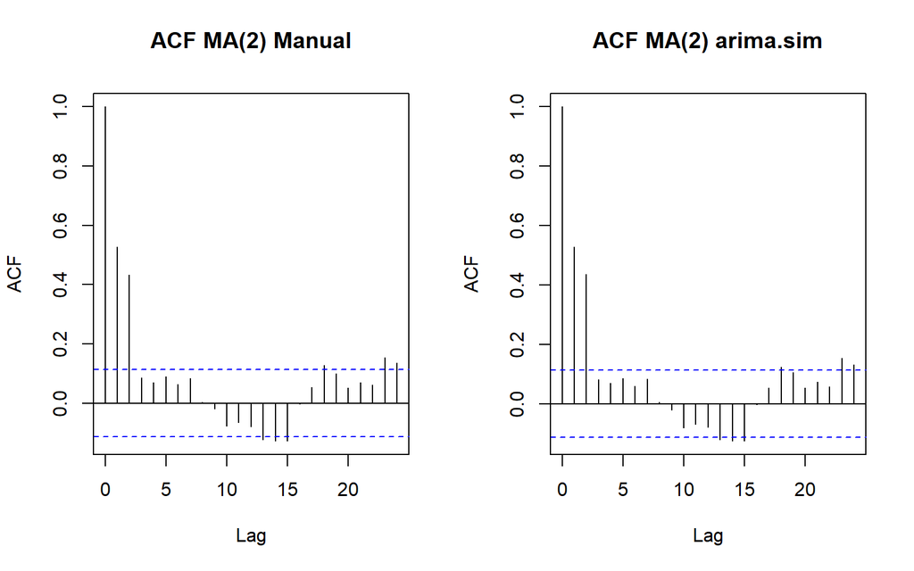

```r
par(mfrow = c(1, 2))
acf(ma2, main = "ACF MA(2) Manual")
acf(ma2.sim, main = "ACF MA(2) arima.sim")
```

```r
par(mfrow = c(1, 1))
```

Plot ACF *cuts off* setelah lag ke-2, sesuai dengan teori bahwa proses MA(2) hanya memiliki autokorelasi yang signifikan sampai lag ke-2.

**Plot PACF**

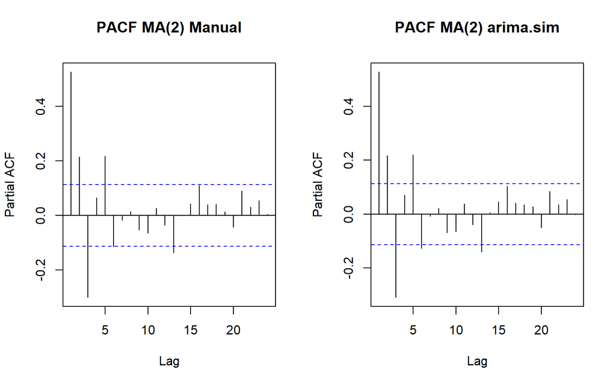

```r
par(mfrow = c(1, 2))
pacf(ma2, main = "PACF MA(2) Manual")
pacf(ma2.sim, main = "PACF MA(2) arima.sim")
```

```r
par(mfrow = c(1, 1))
```

Plot PACF cenderung *tails off* dan membentuk gelombang sinus, sesuai dengan karakteristik teoritis proses MA.

**Plot EACF**

```r
TSA::eacf(ma2)
```

```
## AR/MA
##   0 1 2 3 4 5 6 7 8 9 10 11 12 13
## 0 x x o o o o o o o o o  o  x  x
## 1 x x x o o o o o o o o  o  o  o
## 2 x x x x o o o o o o o  o  o  o
## 3 x x x x x o o o o o o  o  o  o
## 4 x x x x x o o o o o o  o  o  o
## 5 x x x x x o x o o o o  o  o  o
## 6 x x x o x o o x o o o  o  o  o
## 7 x o x o x o o x o o o  o  o  o
```

```r
TSA::eacf(ma2.sim)
```

```
## AR/MA
##   0 1 2 3 4 5 6 7 8 9 10 11 12 13
## 0 x x o o o o o o o o o  o  x  x
## 1 x x x o o o o o o o o  o  o  o
## 2 x x x x o o o o o o o  o  o  o
## 3 x x x x o o o o o o o  o  o  o
## 4 x x x x o o o o o o o  o  o  o
## 5 x x o x x o x o o o o  o  o  o
## 6 o x o o x o o x o o o  o  o  o
## 7 x o x o x o o x o o o  o  o  o
```

Pola segitiga nol pada EACF terlihat mulai pada ordo AR(0) dan ordo MA(2), sesuai dengan model yang dibangkitkan.

**Kesimpulan kestasioneran:** berdasarkan plot time series yang tidak menunjukkan tren, ACF yang *cuts off*, dan PACF yang *tails off*, data MA(2) yang dibangkitkan bersifat **stasioner**.

## c. Scatterplot $Y_t$ dengan $Y_{t-1}$, $Y_{t-2}$, dan $Y_{t-3}$

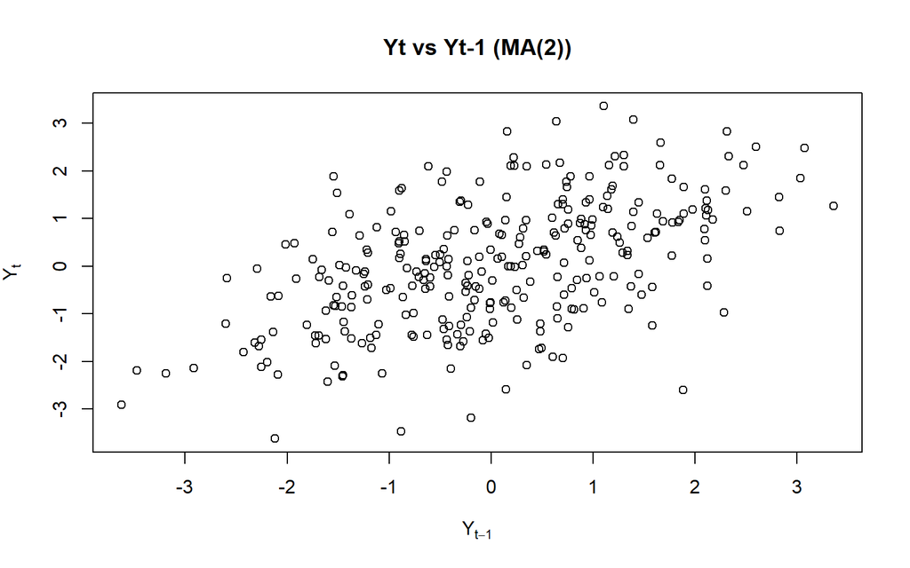

```r
# Yt vs Yt-1
yt_ma2 <- ma2[-1]
yt_1_ma2 <- ma2[-n]
plot(y = yt_ma2, x = yt_1_ma2, xlab = expression(Y[t-1]), ylab = expression(Y[t]),
     main = "Yt vs Yt-1 (MA(2))")
```

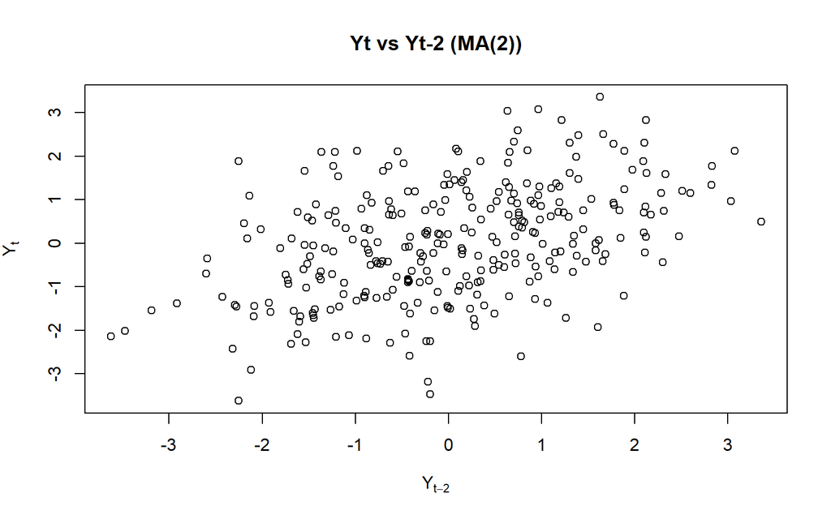

```r
# Yt vs Yt-2
yt_ma2.2 <- ma2[-c(1, 2)]
yt_2_ma2 <- ma2[-c(n - 1, n)]
plot(y = yt_ma2.2, x = yt_2_ma2, xlab = expression(Y[t-2]), ylab = expression(Y[t]),
     main = "Yt vs Yt-2 (MA(2))")
```

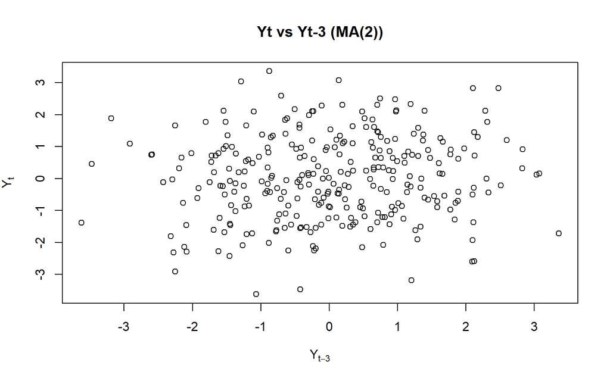

```r
# Yt vs Yt-3
yt_ma2.3 <- ma2[-c(1, 2, 3)]
yt_3_ma2 <- ma2[-c(n - 2, n - 1, n)]
plot(y = yt_ma2.3, x = yt_3_ma2, xlab = expression(Y[t-3]), ylab = expression(Y[t]),
     main = "Yt vs Yt-3 (MA(2))")
```

**Interpretasi**

Terlihat hubungan (linear) positif yang cukup jelas antara $Y_t$ dengan $Y_{t-1}$ dan $Y_{t-2}$, sedangkan antara $Y_t$ dengan $Y_{t-3}$ titik-titiknya menyebar acak tanpa pola. Hal ini sesuai dengan teori bahwa proses MA(2) hanya berkorelasi sampai lag ke-2.

## d. Hitung autokorelasi dari data bangkitan maupun secara teoritis

**Autokorelasi Data Bangkitan**

```r
cor(yt_ma2, yt_1_ma2)      # lag 1, manual
```

```
## [1] 0.5274606
```

```r
cor(yt_ma2.2, yt_2_ma2)    # lag 2, manual
```

```
## [1] 0.4339293
```

```r
cor(yt_ma2.3, yt_3_ma2)    # lag 3, manual
```

```
## [1] 0.08555282
```

```r
acf(ma2.sim, lag.max = 3, plot = FALSE)$acf[2:4]   # lag 1-3, arima.sim
```

```
## [1] 0.52794555 0.43532528 0.08203632
```

**Autokorelasi Teoritis**

Formula autokorelasi teoritis proses MA(2):

$$\rho_1 = \frac{\theta_1 + \theta_1\theta_2}{1+\theta_1^2+\theta_2^2},
\quad
\rho_2 = \frac{\theta_2}{1+\theta_1^2+\theta_2^2}, \quad
\rho_k = 0 \text{ untuk } k \geq 3$$

```r
theta1 <- 0.4
theta2 <- 0.6
denom <- 1 + theta1^2 + theta2^2

rho1.teori <- (theta1 + theta1 * theta2) / denom
rho2.teori <- theta2 / denom
rho3.teori <- 0

hasil.ma2 <- data.frame(
  Lag = c(1, 2, 3),
  Teoritis = c(rho1.teori, rho2.teori, rho3.teori),
  Bangkitan_Manual = c(cor(yt_ma2, yt_1_ma2), cor(yt_ma2.2, yt_2_ma2), cor(yt_ma2.3, yt_3_ma2)),
  Bangkitan_arima.sim = as.numeric(acf(ma2.sim, lag.max = 3, plot = FALSE)$acf[2:4])
)
hasil.ma2
```

```
##   Lag  Teoritis Bangkitan_Manual Bangkitan_arima.sim
## 1   1 0.4210526       0.52746057          0.52794555
## 2   2 0.3947368       0.43392925          0.43532528
## 3   3 0.0000000       0.08555282          0.08203632
```

**Interpretasi**

Nilai autokorelasi dari data bangkitan (baik manual maupun `arima.sim`) mendekati nilai teoritisnya, dengan selisih yang wajar karena sifat acak dari pembangkitan data. Autokorelasi pada lag ke-3 juga mendekati nol, sesuai teori.

# No. 2 : Proses AR(2)

Model yang dibangkitkan:

$$Y_t = \phi_1 Y_{t-1} + \phi_2 Y_{t-2} + e_t, \quad \phi_1 = 0.5,\ \phi_2
= 0.2,\ n = 300$$

## a. Bangkitkan model AR(2) sebanyak 300 data (Manual dan dengan `arima.sim`)

**Manual**

```r
set.seed(1234)
wn.ar2 <- rnorm(n)

ar2 <- wn.ar2[1:2]

for (i in 3:n) {
  ar2[i] <- 0.5 * ar2[i - 1] + 0.2 * ar2[i - 2] + wn.ar2[i]
}
ar2
```

```
##   [1] -1.207065749  0.277429242  0.981742648 -1.799340530 -0.274197047
##   [6]  0.009089263 -0.625034738 -0.857331372 -1.118124633 -1.620566420
##  [11] -1.511100836 -2.078050147 -2.117499135 -1.409900780 -0.168956158
##  [16] -0.476743729 -0.783172602 -1.398130464 -1.692871432  1.289773370
##  [21]  0.440400618 -0.012530914 -0.358733205  0.277716656 -0.626608560
##  [26] -1.705965859 -0.403548921 -1.566623355 -0.879159762 -1.688853153
##  [31]  0.082039017 -0.772344201 -1.079204335 -1.195329068 -2.442598870
##  [36] -2.627984511 -3.982551678 -3.857865933 -3.019737161 -2.747339308
##  [41] -0.528120821 -1.882170996 -1.902074296 -1.608094349 -2.178802110
##  [46] -2.379534243 -2.732845736 -3.094315602 -2.617555067 -2.424490611
##  [51] -3.541787576 -2.837867835 -3.236181057 -3.200626105 -2.409858787
##  [56] -1.281998796  0.524846317 -0.767330024  1.327213880 -0.647667612
##  [61]  0.598197434  2.718556265  1.444157230  0.596156288  0.579304834
##  [66]  2.185968123  0.070237292  1.840139450  2.263681974  1.836341674
##  [71]  1.377800070  0.600699632  0.209385897  0.873119442  2.548707762
```

[output cut: 45 more lines]

**`arima.sim()`**

```r
set.seed(1234)
ar2.sim <- arima.sim(list(order = c(2, 0, 0), ar = c(0.5, 0.2)), n = 300)
ar2.sim
```

```
## Time Series:
## Start = 1
## End = 300
## Frequency = 1
##   [1] -1.7066325607 -0.4040571790 -1.5670108246 -0.8794551485 -1.6890783403
##   [6]  0.0818673463 -0.7724750738 -1.0793041051 -1.1954051279 -2.4426568541
##  [11] -2.6280287147 -3.9825853771 -3.8578916236 -3.0197567460 -2.7473542381
##  [16] -0.5281322030 -1.8821796728 -1.9020809107 -1.6080993919 -2.1788059544
##  [21] -2.3795371734 -2.7328479702 -3.0943173054 -2.6175563658 -2.4244916012
##  [26] -3.5417883306 -2.8378684102 -3.2361814957 -3.2006264394 -2.4098590424
##  [31] -1.2819989901  0.5248461693 -0.7673301373  1.3272137941 -0.6476676781
##  [36]  0.5981973841  2.7185562271  1.4441572006  0.5961562661  0.5793048174
##  [41]  2.1859681101  0.0702372818  1.8401394423  2.2636819683  1.8363416698
##  [46]  1.3778000670  0.6006996293  0.2093858952  0.8731194410  2.5487077608
##  [51]  1.2955793561 -0.2331697165 -0.5810507641 -0.0788975632 -0.4727180494
```

[output cut: 49 more lines]

Cara manual membangkitkan data dengan *loop* yang menjumlahkan 0.5 kali nilai deret satu periode sebelumnya, 0.2 kali nilai deret dua periode sebelumnya, dan white noise saat ini, sesuai bentuk model AR(2). Cara `arima.sim()` menghasilkan pola data yang serupa dengan pembangkitan yang lebih ringkas.

## b. Plot time series, ACF, PACF, EACF, serta identifikasi kestasioneran

**Plot Time Series**

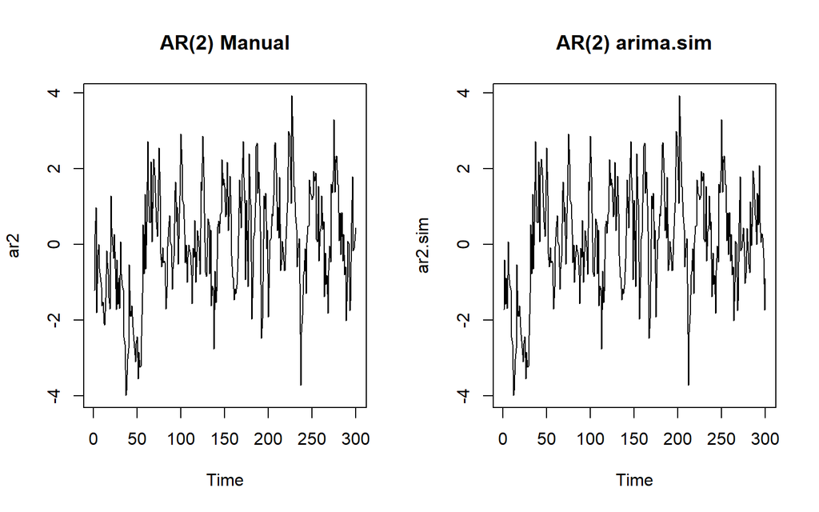

```r
par(mfrow = c(1, 2))
ts.plot(ar2, main = "AR(2) Manual")
ts.plot(ar2.sim, main = "AR(2) arima.sim")
```

```r
par(mfrow = c(1, 1))
```

Data bergerak di sekitar nilai tengah yang konstan tanpa tren, sehingga cenderung **stasioner dalam rataan**.

**Plot ACF**

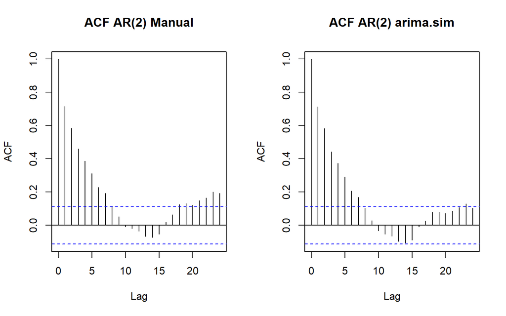

```r
par(mfrow = c(1, 2))
acf(ar2, main = "ACF AR(2) Manual")
acf(ar2.sim, main = "ACF AR(2) arima.sim")
```

```r
par(mfrow = c(1, 1))
```

Plot ACF *tails off* (menurun secara bertahap/membentuk gelombang), sesuai karakteristik teoritis proses AR.

**Plot PACF**

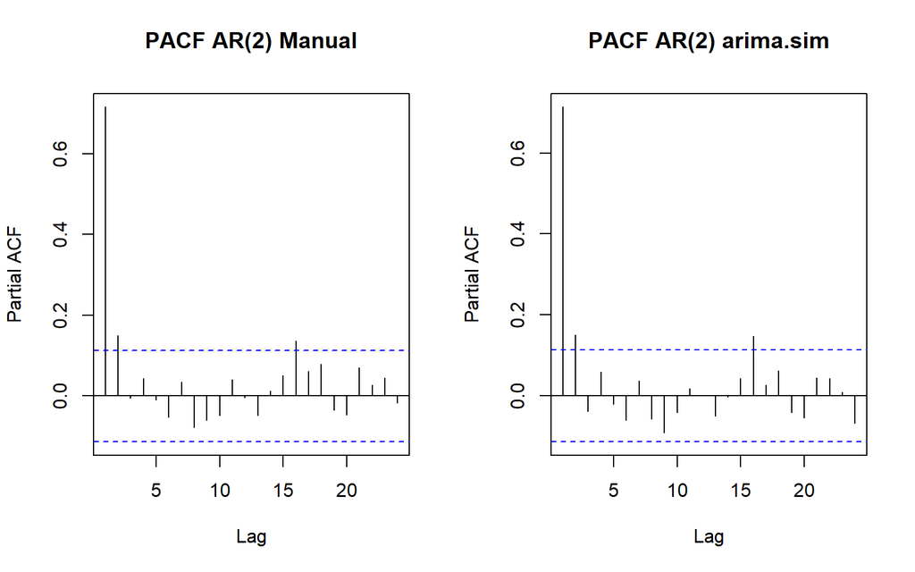

```r
par(mfrow = c(1, 2))
pacf(ar2, main = "PACF AR(2) Manual")
pacf(ar2.sim, main = "PACF AR(2) arima.sim")
```

```r
par(mfrow = c(1, 1))
```

Plot PACF *cuts off* setelah lag ke-2, sesuai teori bahwa proses AR(2) hanya signifikan sampai lag ke-2.

**Plot EACF**

```r
TSA::eacf(ar2)
```

```
## AR/MA
##   0 1 2 3 4 5 6 7 8 9 10 11 12 13
## 0 x x x x x x x o o o o  o  o  o
## 1 x o o o o o o o o o o  o  o  o
## 2 o o o o o o o o o o o  o  o  o
## 3 x x o o o o o o o o o  o  o  o
## 4 x x o o o o o o o o o  o  o  o
## 5 x x o x o o x o o o o  o  o  o
## 6 x x x x o o o o o o o  o  o  o
## 7 x x x o x x o o o o o  o  o  o
```

```r
TSA::eacf(ar2.sim)
```

```
## AR/MA
##   0 1 2 3 4 5 6 7 8 9 10 11 12 13
## 0 x x x x x x x o o o o  o  o  o
## 1 x o o o o o o o o o o  o  o  o
## 2 x o o o o o o o o o o  o  o  o
## 3 x x o o o o o o o o o  o  o  o
## 4 x x o o o o o o o o o  o  o  o
## 5 x x x o o o o o o o o  o  o  o
## 6 x x x o o o o o o o o  o  o  o
## 7 x x x o x x o o o o o  o  o  o
```

**Kesimpulan kestasioneran:** karena $\phi_1+\phi_2 = 0.7 < 1$ (akar-akar persamaan karakteristik berada di luar lingkaran satuan) serta didukung plot time series, ACF yang *tails off*, dan PACF yang *cuts off*, data AR(2) bersifat **stasioner**.

## c. Scatterplot $Y_t$ dengan $Y_{t-1}$, $Y_{t-2}$, dan $Y_{t-3}$

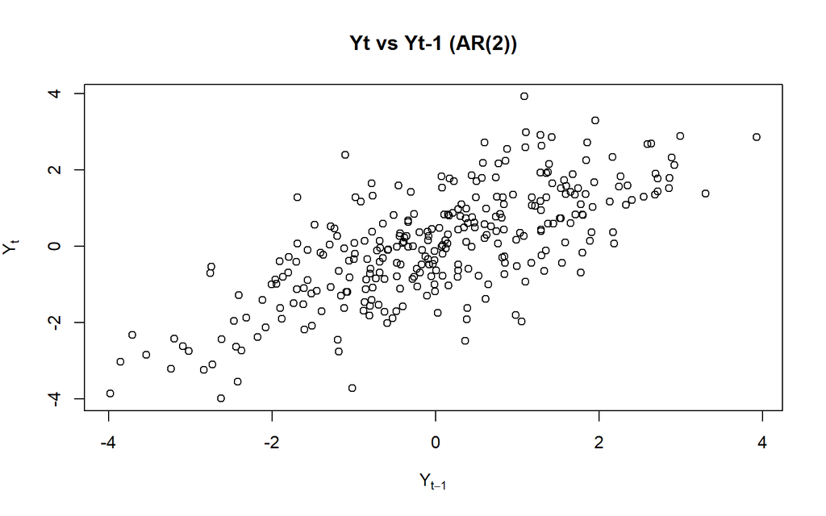

```r
# Yt vs Yt-1
yt_ar2 <- ar2[-1]
yt_1_ar2 <- ar2[-n]
plot(y = yt_ar2, x = yt_1_ar2, xlab = expression(Y[t-1]), ylab = expression(Y[t]),
     main = "Yt vs Yt-1 (AR(2))")
```

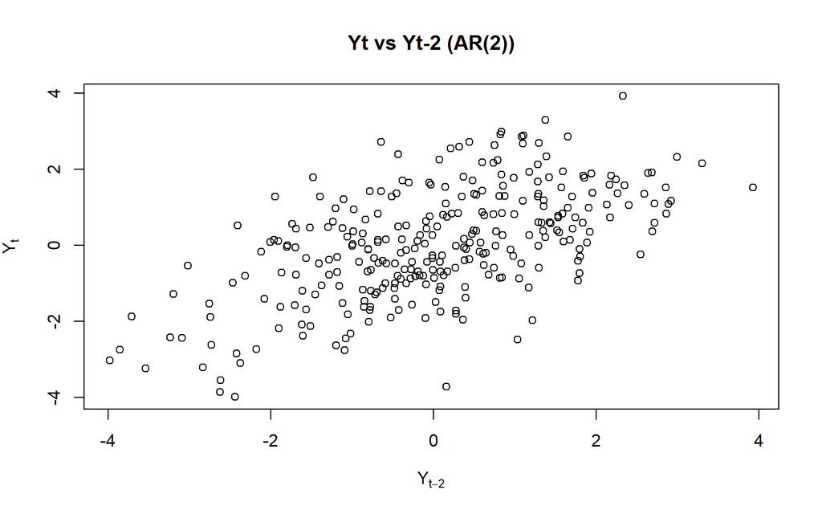

```r
# Yt vs Yt-2
yt_ar2.2 <- ar2[-c(1, 2)]
yt_2_ar2 <- ar2[-c(n - 1, n)]
plot(y = yt_ar2.2, x = yt_2_ar2, xlab = expression(Y[t-2]), ylab = expression(Y[t]),
     main = "Yt vs Yt-2 (AR(2))")
```

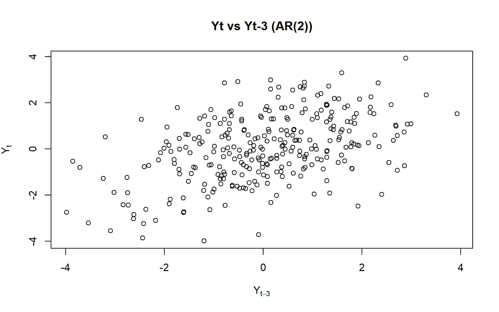

```r
# Yt vs Yt-3
yt_ar2.3 <- ar2[-c(1, 2, 3)]
yt_3_ar2 <- ar2[-c(n - 2, n - 1, n)]
plot(y = yt_ar2.3, x = yt_3_ar2, xlab = expression(Y[t-3]), ylab = expression(Y[t]),
     main = "Yt vs Yt-3 (AR(2))")
```

Terlihat hubungan positif antara $Y_t$ dengan $Y_{t-1}$, $Y_{t-2}$, maupun $Y_{t-3}$, meskipun kekuatan hubungannya melemah seiring bertambahnya lag. Hal ini sesuai sifat proses AR yang ACF-nya *tails off* (tidak langsung terputus pada satu lag tertentu).

## d. Hitung autokorelasi dari data bangkitan maupun secara teoritis

**Autokorelasi Data Bangkitan**

```r
cor(yt_ar2, yt_1_ar2)      # lag 1, manual
```

```
## [1] 0.7165728
```

```r
cor(yt_ar2.2, yt_2_ar2)    # lag 2, manual
```

```
## [1] 0.5856318
```

```r
cor(yt_ar2.3, yt_3_ar2)    # lag 3, manual
```

```
## [1] 0.4609517
```

```r
acf(ar2.sim, lag.max = 3, plot = FALSE)$acf[2:4]   # lag 1-3, arima.sim
```

```
## [1] 0.7135307 0.5828365 0.4427355
```

**Autokorelasi Teoritis**

Formula autokorelasi teoritis proses AR(2) (persamaan Yule-Walker):

$$\rho_1 = \frac{\phi_1}{1-\phi_2}, \quad
\rho_2 = \phi_2+\phi_1\rho_1, \quad
\rho_k = \phi_1\rho_{k-1}+\phi_2\rho_{k-2}\ (k\geq3)$$

```r
phi1 <- 0.5
phi2 <- 0.2

rho1.teori.ar <- phi1 / (1 - phi2)
rho2.teori.ar <- phi2 + phi1 * rho1.teori.ar
rho3.teori.ar <- phi1 * rho2.teori.ar + phi2 * rho1.teori.ar

hasil.ar2 <- data.frame(
  Lag = c(1, 2, 3),
  Teoritis = c(rho1.teori.ar, rho2.teori.ar, rho3.teori.ar),
  Bangkitan_Manual = c(cor(yt_ar2, yt_1_ar2), cor(yt_ar2.2, yt_2_ar2), cor(yt_ar2.3, yt_3_ar2)),
  Bangkitan_arima.sim = as.numeric(acf(ar2.sim, lag.max = 3, plot = FALSE)$acf[2:4])
)
hasil.ar2
```

```
##   Lag Teoritis Bangkitan_Manual Bangkitan_arima.sim
## 1   1  0.62500        0.7165728           0.7135307
## 2   2  0.51250        0.5856318           0.5828365
## 3   3  0.38125        0.4609517           0.4427355
```

Nilai autokorelasi dari data bangkitan (manual maupun `arima.sim`) mendekati nilai teoritisnya pada tiap lag, dan besarnya autokorelasi menurun secara bertahap seiring bertambahnya lag, sesuai teori AR.

# No. 3 : Proses ARMA(2,2)

Model yang dibangkitkan:

$$Y_t = \phi_1 Y_{t-1} + \phi_2 Y_{t-2} + e_t + \theta_1 e_{t-1} +
\theta_2 e_{t-2}$$

dengan $\theta_1 = 0.4$, $\theta_2 = 0.6$, $\phi_1 = 0.5$, $\phi_2 = 0.2$, dan $n = 300$.

## a. Bangkitkan model ARMA(2,2) sebanyak 300 data (Manual dan `arima.sim`)

**Cara Manual**

```r
set.seed(1234)
wn.arma22 <- rnorm(n)

arma22 <- wn.arma22[1:2]

for (i in 3:n) {
  arma22[i] <- 0.5 * arma22[i - 1] + 0.2 * arma22[i - 2] +
    wn.arma22[i] + 0.4 * wn.arma22[i - 1] + 0.6 * wn.arma22[i - 2]
}
arma22
```

```
##   [1] -1.20706575  0.27742924  0.36847490 -1.50574039 -0.53766490 -1.29969338
##   [7] -0.87222246 -1.16894421 -1.88686532 -2.62101924 -2.85976172 -3.67737093
##  [13] -3.87256190 -3.51682974 -2.01340200 -1.39787953 -1.08104743 -2.00187014
##  [19] -2.72540011 -0.22882482 -0.06137315  0.93599896 -0.10064445  0.12583632
##  [25] -0.73142392 -1.79048404 -1.46228520 -2.75191579 -1.74816209 -2.98066156
##  [31] -1.12112807 -1.75293957 -1.33899414 -2.09047491 -3.56829700 -4.32225497
##  [37] -6.49933032 -7.02769676 -6.95242937 -6.26996504 -3.43890746 -3.74182948
##  [43] -2.97182019 -3.49823048 -3.96328734 -4.21591391 -4.99194239 -5.61517573
##  [49] -5.49498973 -5.32810275 -6.08211743 -5.70927767 -6.49640107 -6.19781948
##  [55] -5.63181806 -4.16631812 -1.43386859 -1.32659086  1.33518960 -0.57718012
##  [61]  1.13545868  2.56923464  2.89049817  2.80495292  1.68426167  2.77538382
##  [67]  1.29220743  3.17981523  3.04188012  3.84589813  3.47054592  2.25362466
##  [73]  1.27634579  1.31729358  3.02358708  2.83893413  1.81428668  0.10302896
##  [79] -0.45121970 -0.85290753 -0.66635425 -0.93510416 -2.14779642 -2.08562341
##  [85] -1.51503473 -0.24121274  0.91556687  0.64537308  0.48311177 -1.14217407
```

[output cut: 35 more lines]

**`arima.sim()`**

```r
set.seed(1234)
arma22.sim <- arima.sim(list(order = c(2, 0, 2), ar = c(0.5, 0.2), ma = c(0.4, 0.6)), n = 300)
arma22.sim
```

```
## Time Series:
## Start = 1
## End = 300
## Frequency = 1
##   [1] -2.75189059 -1.74814288 -2.98064692 -1.12111691 -1.75293106 -1.33898765
##   [7] -2.09046996 -3.56829323 -4.32225209 -6.49932813 -7.02769509 -6.95242810
##  [13] -6.26996407 -3.43890672 -3.74182891 -2.97181976 -3.49823015 -3.96328709
##  [19] -4.21591372 -4.99194225 -5.61517562 -5.49498965 -5.32810268 -6.08211738
##  [25] -5.70927763 -6.49640104 -6.19781946 -5.63181804 -4.16631811 -1.43386858
##  [31] -1.32659085  1.33518960 -0.57718012  1.13545868  2.56923465  2.89049818
##  [37]  2.80495292  1.68426168  2.77538382  1.29220743  3.17981524  3.04188012
##  [43]  3.84589813  3.47054592  2.25362466  1.27634579  1.31729358  3.02358708
##  [49]  2.83893413  1.81428668  0.10302896 -0.45121970 -0.85290753 -0.66635425
##  [55] -0.93510416 -2.14779642 -2.08562341 -1.51503473 -0.24121274  0.91556687
##  [61]  0.64537308  0.48311177 -1.14217407 -1.12039092 -1.27141453  0.91636167
```

[output cut: 39 more lines]

Cara manual menggabungkan komponen AR (0.5 kali nilai deret satu periode sebelumnya + 0.2 kali dua periode sebelumnya) dan komponen MA (white noise saat ini + 0.4 kali white noise satu periode sebelumnya + 0.6 kali dua periode sebelumnya), sesuai model ARMA(2,2) di atas. Fungsi `arima.sim()` menghasilkan pola data yang serupa secara langsung.

## b. Plot time series, ACF, PACF, EACF, serta identifikasi kestasioneran

**Plot Time Series**

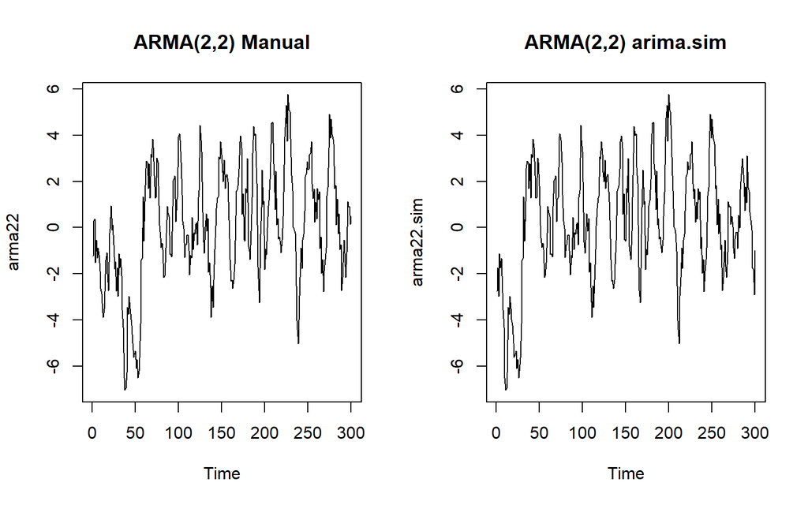

```r
par(mfrow = c(1, 2))
ts.plot(arma22, main = "ARMA(2,2) Manual")
ts.plot(arma22.sim, main = "ARMA(2,2) arima.sim")
```

```r
par(mfrow = c(1, 1))
```

Data bergerak di sekitar nilai tengah yang konstan tanpa tren maupun perubahan lebar pita yang berarti, sehingga cenderung **stasioner dalam rataan**.

**Plot ACF**

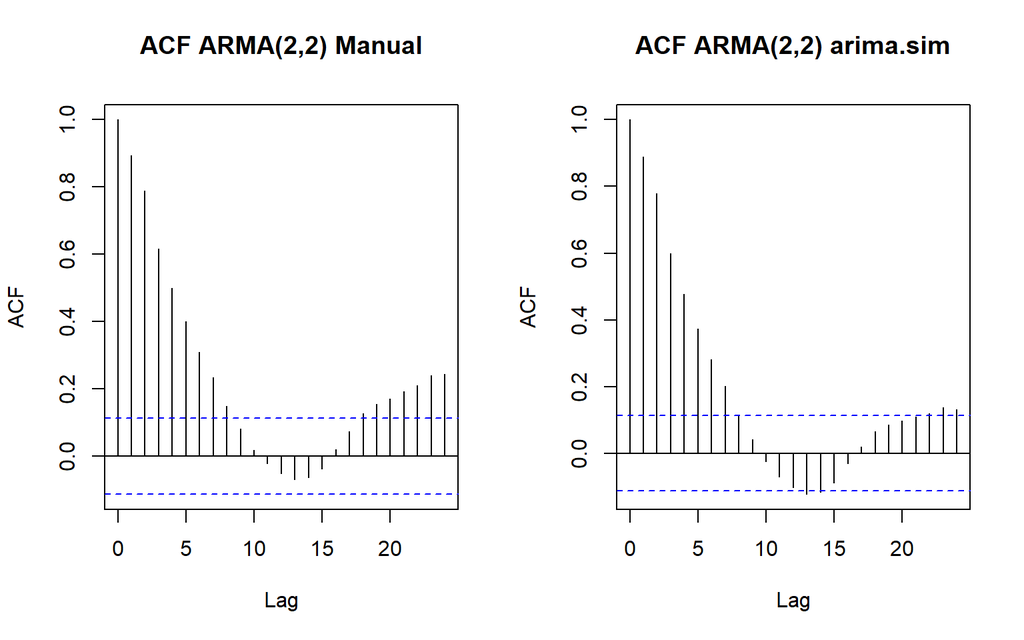

```r
par(mfrow = c(1, 2))
acf(arma22, main = "ACF ARMA(2,2) Manual")
acf(arma22.sim, main = "ACF ARMA(2,2) arima.sim")
```

```r
par(mfrow = c(1, 1))
```

Plot ACF *tails off*, sesuai karakteristik proses ARMA yang memiliki komponen AR.

**Plot PACF**

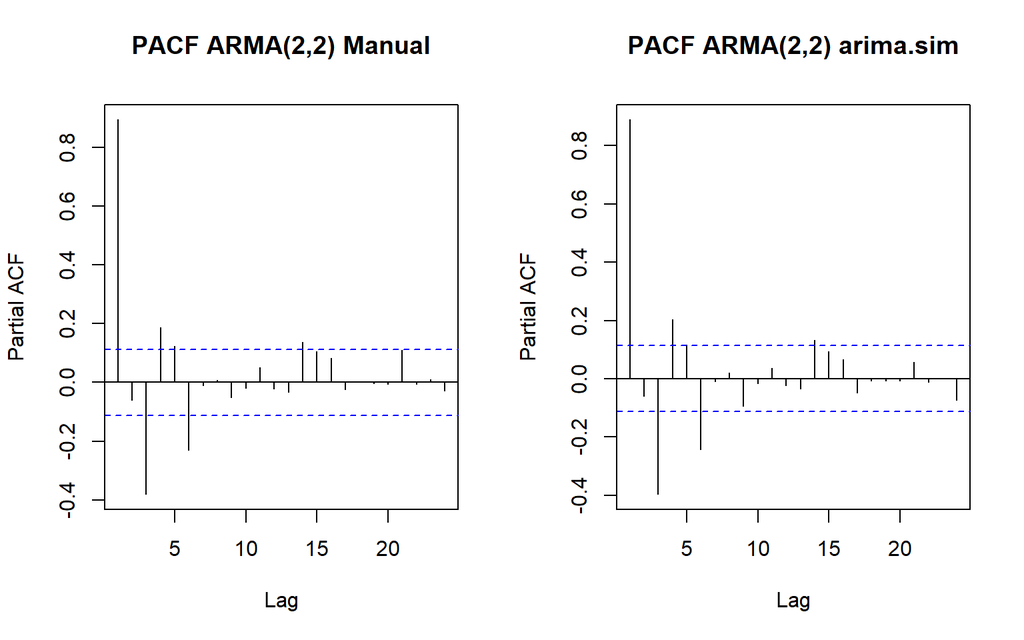

```r
par(mfrow = c(1, 2))
pacf(arma22, main = "PACF ARMA(2,2) Manual")
pacf(arma22.sim, main = "PACF ARMA(2,2) arima.sim")
```

```r
par(mfrow = c(1, 1))
```

Plot PACF juga *tails off*, sesuai karakteristik proses ARMA yang memiliki komponen MA.

**Plot EACF**

```r
TSA::eacf(arma22)
```

```
## AR/MA
##   0 1 2 3 4 5 6 7 8 9 10 11 12 13
## 0 x x x x x x x x o o o  o  o  o
## 1 o x o o o o x o o o o  o  o  o
## 2 x x o o o o x o o o o  o  o  o
## 3 x x o x o o x o o o o  o  o  o
## 4 x x x x o o x o o o o  o  o  o
## 5 x x x x x x x o o o o  o  o  o
## 6 o o x o x x o o o o o  o  o  o
## 7 o o x o x x o x o o o  o  o  o
```

```r
TSA::eacf(arma22.sim)
```

```
## AR/MA
##   0 1 2 3 4 5 6 7 8 9 10 11 12 13
## 0 x x x x x x x o o o o  o  x  o
## 1 o x o o o o x o o o o  o  o  o
## 2 x x o o o o o o o o o  o  o  o
## 3 x x x x o o o o o o o  o  o  o
## 4 x x x x o o o o o o o  o  o  o
## 5 x x x x x x x o o o o  o  o  o
## 6 o o x o x x o o o o o  o  o  o
## 7 x o x x x x o x o o o  o  o  o
```

Pola segitiga nol pada EACF berada pada ordo AR(2) dan ordo MA(2), sesuai model yang dibangkitkan.

**Kesimpulan kestasioneran:** karena ACF dan PACF sama-sama *tails off* (tidak ada yang *cuts off* tegas) serta plot time series tidak menunjukkan tren, data ARMA(2,2) bersifat **stasioner**.

## c. Scatterplot $Y_t$ dengan $Y_{t-1}$, $Y_{t-2}$, dan $Y_{t-3}$

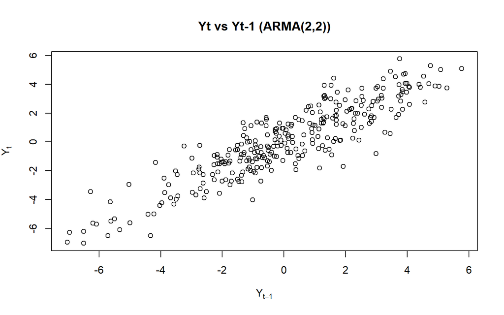

```r
# Yt vs Yt-1
yt_arma22 <- arma22[-1]
yt_1_arma22 <- arma22[-n]
plot(y = yt_arma22, x = yt_1_arma22, xlab = expression(Y[t-1]), ylab = expression(Y[t]),
     main = "Yt vs Yt-1 (ARMA(2,2))")
```

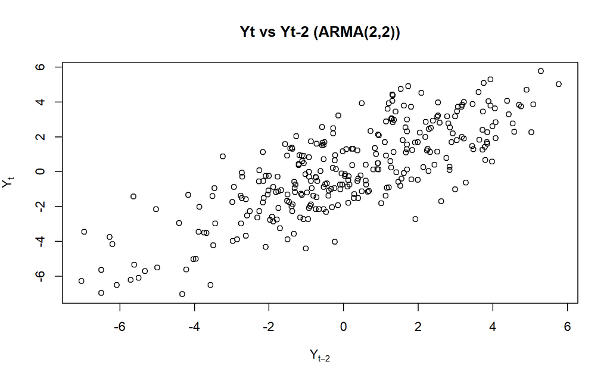

```r
# Yt vs Yt-2
yt_arma22.2 <- arma22[-c(1, 2)]
yt_2_arma22 <- arma22[-c(n - 1, n)]
plot(y = yt_arma22.2, x = yt_2_arma22, xlab = expression(Y[t-2]), ylab = expression(Y[t]),
     main = "Yt vs Yt-2 (ARMA(2,2))")
```

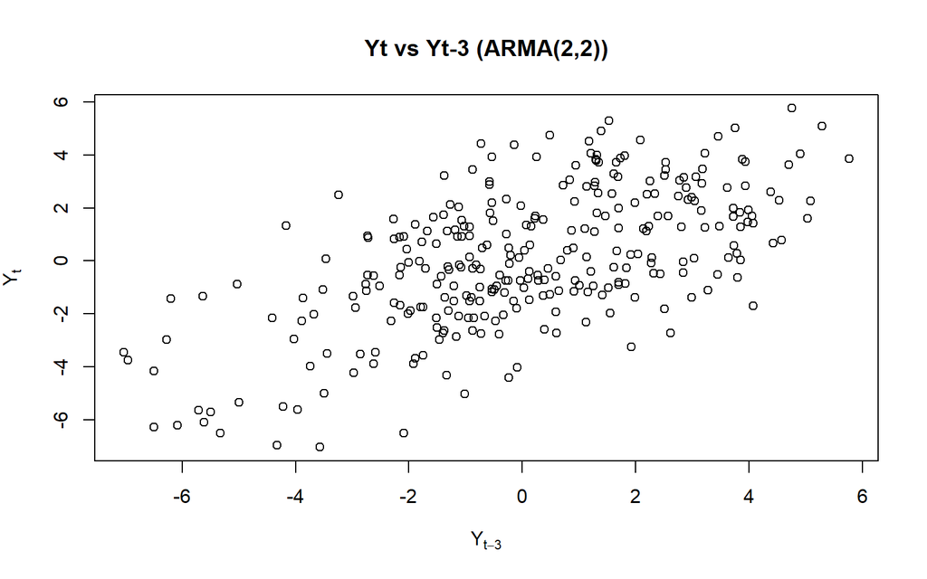

```r
# Yt vs Yt-3
yt_arma22.3 <- arma22[-c(1, 2, 3)]
yt_3_arma22 <- arma22[-c(n - 2, n - 1, n)]
plot(y = yt_arma22.3, x = yt_3_arma22, xlab = expression(Y[t-3]), ylab = expression(Y[t]),
     main = "Yt vs Yt-3 (ARMA(2,2))")
```

**Interpretasi**

Terlihat hubungan positif antara $Y_t$ dengan $Y_{t-1}$, $Y_{t-2}$, dan $Y_{t-3}$, meskipun kekuatan hubungannya semakin melemah seiring bertambahnya lag. Hal ini sesuai sifat komponen AR pada model ARMA yang menyebabkan autokorelasi meluruh secara bertahap.

## d. Hitung autokorelasi dari data bangkitan maupun secara teoritis

**Autokorelasi Data Bangkitan**

```r
cor(yt_arma22, yt_1_arma22)      # lag 1, manual
```

```
## [1] 0.8946787
```

```r
cor(yt_arma22.2, yt_2_arma22)    # lag 2, manual
```

```
## [1] 0.78822
```

```r
cor(yt_arma22.3, yt_3_arma22)    # lag 3, manual
```

```
## [1] 0.6177423
```

```r
acf(arma22.sim, lag.max = 3, plot = FALSE)$acf[2:4]   # lag 1-3, arima.sim
```

```
## [1] 0.8893625 0.7786694 0.5983096
```

**Autokorelasi Teoritis**

Untuk proses ARMA(p,q), autokorelasi teoritis eksak dapat dihitung dengan fungsi `ARMAacf()` di R (didasarkan pada representasi $MA(\infty)$ dari model ARMA), karena rumus tertutupnya jauh lebih rumit dibanding kasus MA maupun AR murni:

```r
rho.teori.arma <- ARMAacf(ar = c(0.5, 0.2), ma = c(0.4, 0.6), lag.max = 3)
rho.teori.arma
```

```
##         0         1         2         3
## 1.0000000 0.8591993 0.7491908 0.5464353
```

```r
hasil.arma22 <- data.frame(
  Lag = c(1, 2, 3),
  Teoritis = as.numeric(rho.teori.arma[2:4]),
  Bangkitan_Manual = c(cor(yt_arma22, yt_1_arma22), cor(yt_arma22.2, yt_2_arma22), cor(yt_arma22.3, yt_3_arma22)),
  Bangkitan_arima.sim = as.numeric(acf(arma22.sim, lag.max = 3, plot = FALSE)$acf[2:4])
)
hasil.arma22
```

```
##   Lag  Teoritis Bangkitan_Manual Bangkitan_arima.sim
## 1   1 0.8591993        0.8946787           0.8893625
## 2   2 0.7491908        0.7882200           0.7786694
## 3   3 0.5464353        0.6177423           0.5983096
```

Nilai autokorelasi dari data bangkitan (manual maupun `arima.sim`) mendekati nilai teoritisnya pada lag 1, 2, dan 3, dengan selisih yang relatif kecil karena sifat acak dari pembangkitan data.